# Lab 11 - t-test

Nick Sumpter (Edited by Eddie-Williams Owiredu & Guy Twa)

2023-09-25

## Today’s Lab

This lab covers material for simple t-tests and their assumptions. This is the most basic form of testing for a difference in means between only two groups of subjects or conditions. Information in this lab covers both independent and dependent (paired) t-tests.

## Loading Packages and Data

```r
library(car)
library(pastecs)
library(tidyverse)

theme_set(theme_bw())

setwd("~/Documents/GRD770/Lab 11 - t-test")

load("T-test.RData")

source("~/Documents/GRD770/functions/functions.R")

mtcars <- mtcars
```

### Getting to Know Your Data

The `T-test.RData` file contains two different datasets, `sniff.ind` and `sniff.dep`. The `sniff.ind` dataset has the following two variables:

- `group` (factor, 2 levels): which group the mouse is a part of. Either control or anesthetic treatment (Sevo)
- `time` (numeric): time spent sniffing another mouse

The `sniff.dep` dataset has the following 3 variables:

- `ID` (numeric): a numeric ID for each of the 29 total mice
- `familiar` (numeric): time spent sniffing a familiar mouse
- `novel` (numeric): time spent sniffing a novel mouse

These data are examples of different socialization experiments. Does an anesthetic cause a difference in sniff time of another mouse (`sniff.ind` data)? Also, does sniff time depend on familiarity with another mouse (`sniff.dep` data)?

Let’s go ahead and plot the mean time in the two groups for each dataset. For the dependent dataset, let’s connect the points with lines to show that they are repeated measures. To connect the points, we will use the geom_line function, setting the `group` aesthetic to the ID variable.

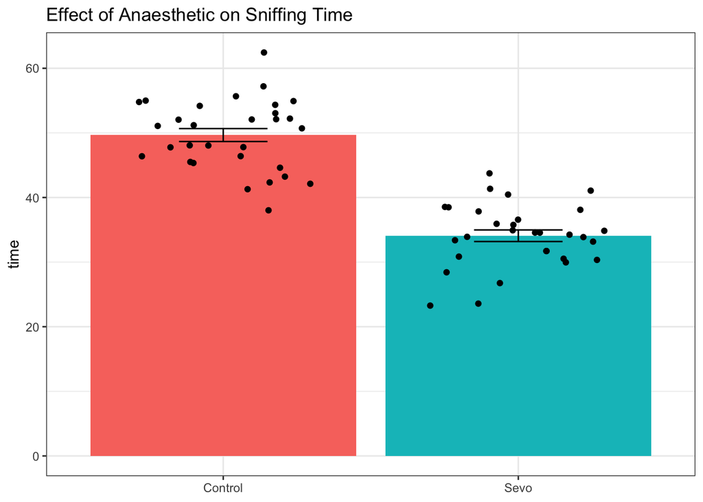

```r
ggplot(data = sniff.ind, mapping = aes(x = group, y = time)) +
  geom_bar(mapping = aes(fill = group), stat = "summary", fun = "mean", show.legend = FALSE) +
  geom_errorbar(stat = "summary", fun.data = "mean_se", width = 0.3) +
  geom_jitter(width = 0.3) +
  labs(title = "Effect of Anaesthetic on Sniffing Time") +
  theme_bw() +
  theme(axis.title.x = element_blank())
```

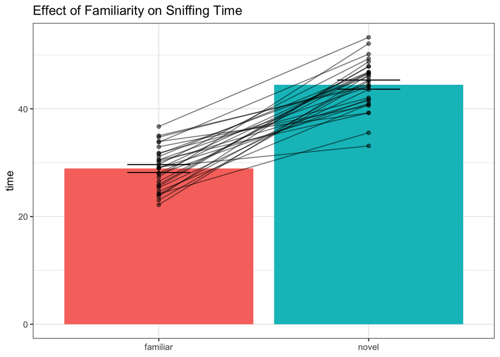

```r
# For the dependent dataset, we will pivot it into the longer format for easier plotting

sniff.dep2 <- sniff.dep %>%
  pivot_longer(cols = familiar:novel,
               names_to = "group",
               values_to = "time")

# Setting alpha to 0.5 for the points and lines makes them slightly see-through

ggplot(data = sniff.dep2, mapping = aes(x = group, y = time)) +
  geom_bar(mapping = aes(fill = group), stat = "summary", fun = "mean", show.legend = FALSE) +
  geom_errorbar(stat = "summary", fun.data = "mean_se", width = 0.3) +
  geom_point(alpha = 0.5) +
  geom_line(mapping = aes(group = ID), alpha = 0.5) +
  labs(title = "Effect of Familiarity on Sniffing Time") +
  theme_bw() +
  theme(axis.title.x = element_blank())
```

## Assumptions of a t-test

1. Independence (independent t-test only)
2. Homogeneity of variance across groups (independent t-test only)
3. Normality of the variable within each group (independent t-test only)
4. Normality of the difference between groups (dependent t-test only)

We know that the independence assumption has been met for the `sniff.ind` dataset as the mice in each group are different.

Let’s quickly assess normality and homogeneity of variance for the `sniff.ind` dataset:

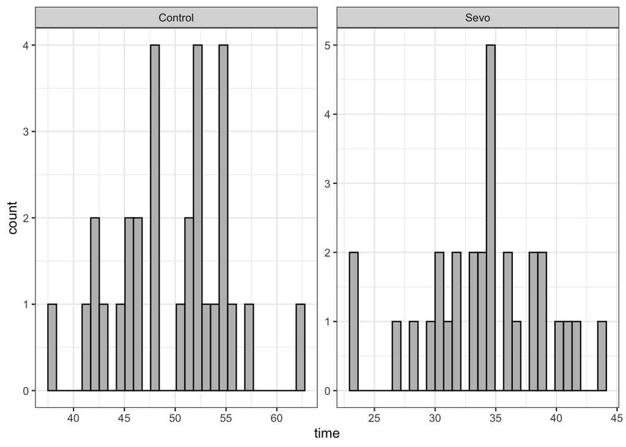

```r
# Histogram
ggplot(data = sniff.ind, mapping = aes(x = time)) +
  geom_histogram(bins = 30, fill = 'gray', color = 'black') +
  facet_wrap(~ group, scales = "free")
```

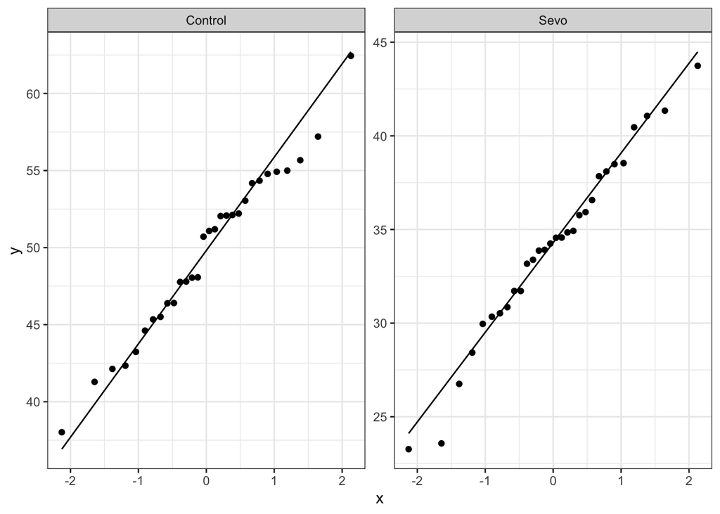

```r
# Q-Q plot
ggplot(data = sniff.ind, mapping = aes(sample = time)) +
  geom_qq() +
  geom_qq_line() +
  facet_wrap(~ group, scales = "free")
```

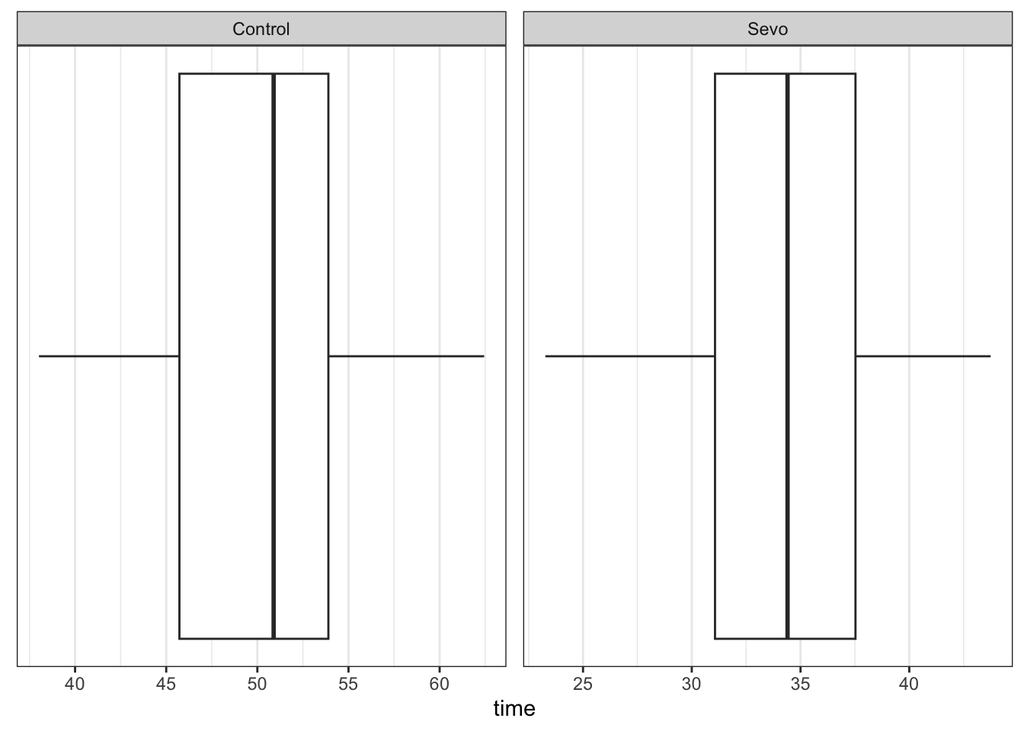

```r
# Boxplot
ggplot(data = sniff.ind, mapping = aes(x = time)) +
  geom_boxplot() +
  theme(axis.ticks.y = element_blank(),
        axis.text.y = element_blank(),
        panel.grid.major.y = element_blank(),
        panel.grid.minor.y = element_blank()) +
  facet_wrap(~ group, scales = "free")
```

```r
stat.desc.clean(dataset = sniff.ind, variable = time, group)
```

```
## # A tibble: 2 × 7
## # Groups:   group [2]
##   group   skewness skew.2SE kurtosis kurt.2SE normtest.W normtest.p
##   <fct>      <dbl>    <dbl>    <dbl>    <dbl>      <dbl>      <dbl>
## 1 Control  -0.0337  -0.0394   -0.531   -0.319      0.981      0.849
## 2 Sevo     -0.288   -0.338    -0.281   -0.169      0.978      0.783
```

```r
leveneTest(time ~ group, data = sniff.ind)
```

```
## Levene's Test for Homogeneity of Variance (center = median)
##       Df F value Pr(>F)
## group  1  0.8933 0.3485
##       58
```

So, all assumptions seem to have been met for the `sniff.ind` dataset. Now, let’s test for normality of the differences between groups in the `sniff.dep` dataset. This will require us to create a new column that represents the difference between familiar and novel sniff time for each mouse.

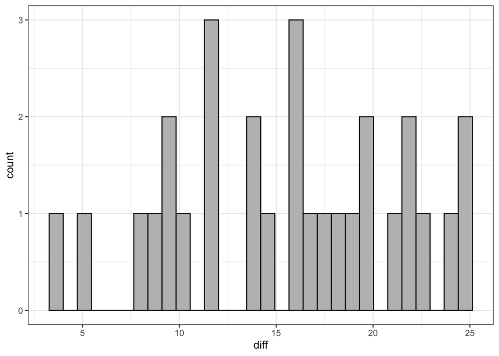

```r
sniff.dep3 <- sniff.dep %>%
  mutate(diff = novel - familiar)

# Histogram
ggplot(data = sniff.dep3, mapping = aes(x = diff)) +
  geom_histogram(bins = 30, fill = 'gray', color = 'black')
```

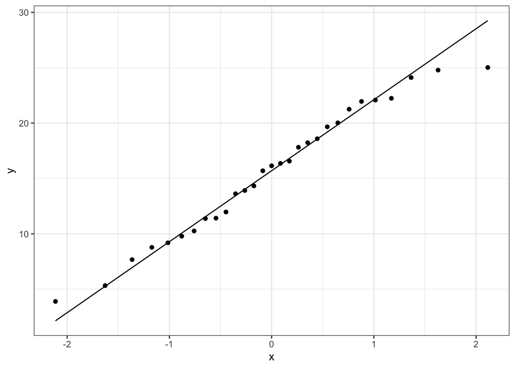

```r
# Q-Q plot
ggplot(data = sniff.dep3, mapping = aes(sample = diff)) +
  geom_qq() +
  geom_qq_line()
```

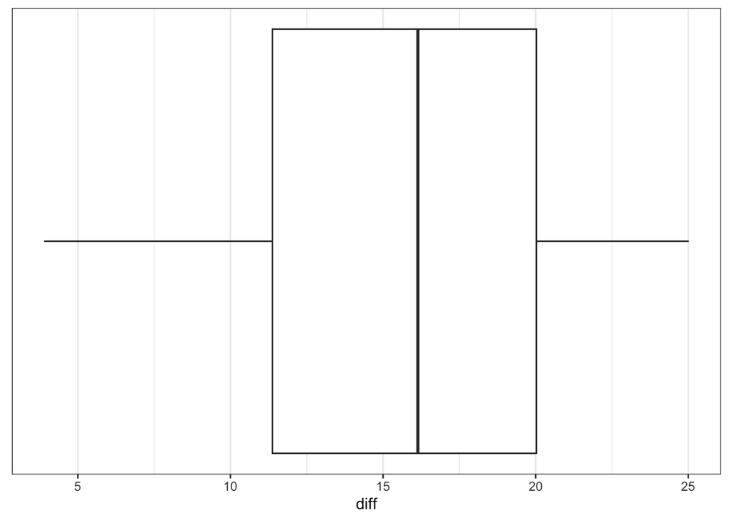

```r
# Boxplot
ggplot(data = sniff.dep3, mapping = aes(x = diff)) +
  geom_boxplot() +
  theme(axis.ticks.y = element_blank(),
        axis.text.y = element_blank(),
        panel.grid.major.y = element_blank(),
        panel.grid.minor.y = element_blank())
```

```r
stat.desc.clean(dataset = sniff.dep3, variable = diff)
```

```
## # A tibble: 1 × 6
##   skewness skew.2SE kurtosis kurt.2SE normtest.W normtest.p
##      <dbl>    <dbl>    <dbl>    <dbl>      <dbl>      <dbl>
## 1   -0.143   -0.165    -1.07   -0.633      0.971      0.599
```

So as you can see, the differences actually seem to be normal, so we can carry out our test.

## Running a t-test

Performing a t-test is fairly straightforward. The test can be done with either long data (groups are in a single column) or wide data (groups in different columns). The only difference is how you specify the data. Both forms can be seen below:

For wide data: `t.test(x, y, paired = FALSE)`

- `x`: data for the first group
- `y`: data for the second group
- `paired`: whether the test is independent (FALSE) or dependent (TRUE). FALSE by default

For long data: `t.test(formula, data, paired = FALSE)`

- `formula`: formula detailing dependent continuous variable as a function of the grouping variable. This is similar to the formula used in the `lm` function from previous labs.
- `data`: the dataframe to use
- `paired`: same as above

### Independent t-test

Let’s perform an independent t-test on the `time` variable in our `sniff.ind` dataset, testing for a difference in mean sniffing time between the two groups (Sevo vs Control).

```r
t.test(formula = time ~ group, data = sniff.ind, paired = FALSE)
```

```
##
##  Welch Two Sample t-test
##
## data:  time by group
## t = 11.587, df = 57.285, p-value < 2.2e-16
## alternative hypothesis: true difference in means between group Control and group Sevo is not equal to 0
## 95 percent confidence interval:
##  12.88985 18.27501
## sample estimates:
## mean in group Control    mean in group Sevo
##              49.66456              34.08213
```

The output table gives the t-statistic, degrees of freedom, and p-value as well as the 95% CI and the group means. Note that this t-test uses the Welch approximation for the degrees of freedom, resulting in a non-integer df value.

For the report, you will want to calculate the mean and standard deviation of your outcome variable within each group. We will use the `group_by` and `summarize` functions for this:

```r
sniff.ind %>%
  group_by(group) %>%
  summarize(mean = mean(time),
            sd = sd(time))
```

```
## # A tibble: 2 × 3
##   group    mean    sd
##   <fct>   <dbl> <dbl>
## 1 Control  49.7  5.49
## 2 Sevo     34.1  4.91
```

**Report**: On average, mice treated with a Control anesthetic spent more time sniffing other mice (mean = 49.66 ± 5.49 seconds) compared to mice in the Sevo anesthetic treatment group (mean = 34.08 ± 4.91 seconds). This difference in means was significant (t(57.3) = 11.59, p < 2.2e-16).

### Dependent t-test

We hypothesize that there will be a significant difference in socialization time based on whether a mouse is interacting with a novel mouse or a familiar mouse. Socialization time is measured as time spent sniffing another mouse introduced to the experimental mouse’s cage. Use the `sniff.dep` dataset and the dependent sample t-test to test this.

```r
t.test(sniff.dep$familiar, sniff.dep$novel, paired = TRUE)
```

```
##
##  Paired t-test
##
## data:  sniff.dep$familiar and sniff.dep$novel
## t = -14.226, df = 28, p-value = 2.438e-14
## alternative hypothesis: true mean difference is not equal to 0
## 95 percent confidence interval:
##  -17.83151 -13.34261
## sample estimates:
## mean difference
##       -15.58706
```

```r
sniff.dep2 %>%
  group_by(group) %>%
  summarize(mean(time),
            sd(time))
```

```
## # A tibble: 2 × 3
##   group    `mean(time)` `sd(time)`
##   <chr>           <dbl>      <dbl>
## 1 familiar         28.9       3.95
## 2 novel            44.5       4.57
```

**Report**: On average, time spent sniffing a novel mouse was higher (mean = 44.49 ± 4.57 seconds) compared to sniffing a familiar mouse (mean = 28.91 ± 3.95 seconds). This difference in means was significant (t(28) = -14.23, p = 2.44e-14).

## Independent Practice

Using the `mtcars` dataset, test for differences in horsepower (stored in the hp variable) between the automatic and manual transmission types (stored in the am variable: 0 = auto, 1 = manual).

1. Get to know your data: describe your variables and their distribution
2. Assumptions
   1. Determine whether assumptions are met
   2. If assumptions are not met, describe what you will do to account for this
3. Run the appropriate test
4. Report your findings as you would describe them in the results section